# Incarceation Trends and Black People Report

Hao Chen

2/25/2022

## Introduction

According to the data published from Vera about the incarceration trends in the U.S, the proportion of colored people in jail is different across the country. This report emphases black people in jail and their proportion to the total jail population. The reason behind this is the increasing upheaval of black lifes matter movement and interests in the black jail rate. This can also lead to reconsideration about the sterotype of black person and crime.

## Summary

According to the data from [statistics](https://github.com/vera-institute/incarceration-trends.git/incarceration_trends.csv), Los Angeles County have the highest black jail population. Adair Countyhas the lowest black jail population. The average black jail population is 92.0643013.Caswell County has the highest proportion of black person in jail. LA county as the county that has the highest black jail population, the black jail popluation has changed -0.0565683 in the last 10 years.

## Jail population in LA county by race chart

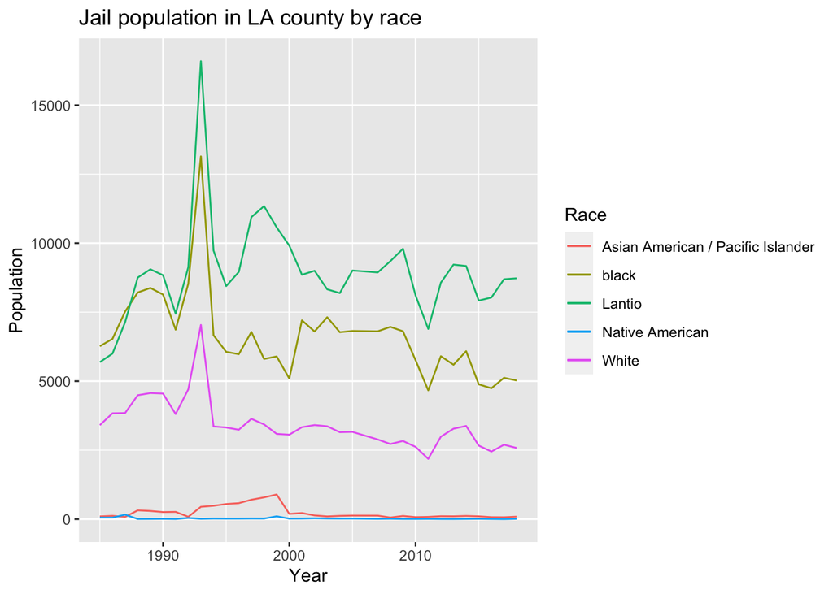

## The relationship between total population and black in jail pop in top 10 populated counties in different states

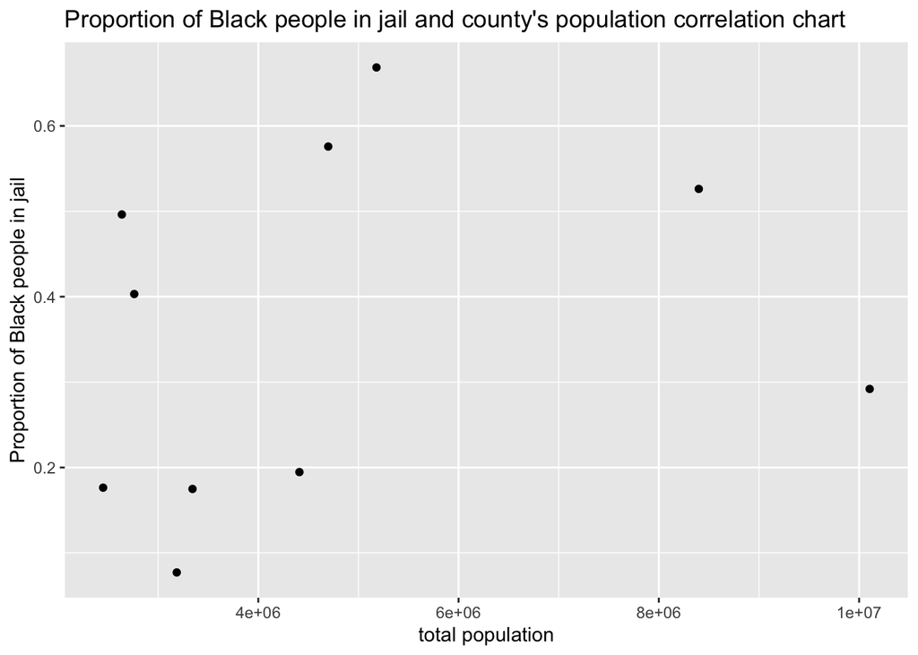

This chart shows the proportion of black proportion in jail in the top 10 populated counties. As in the chart, we can see there is no relationship between the population of a county and its black ratio in jail. It means county with higher population has no connection to its black proportion in jail.

## Black people in jail proportion in U.S

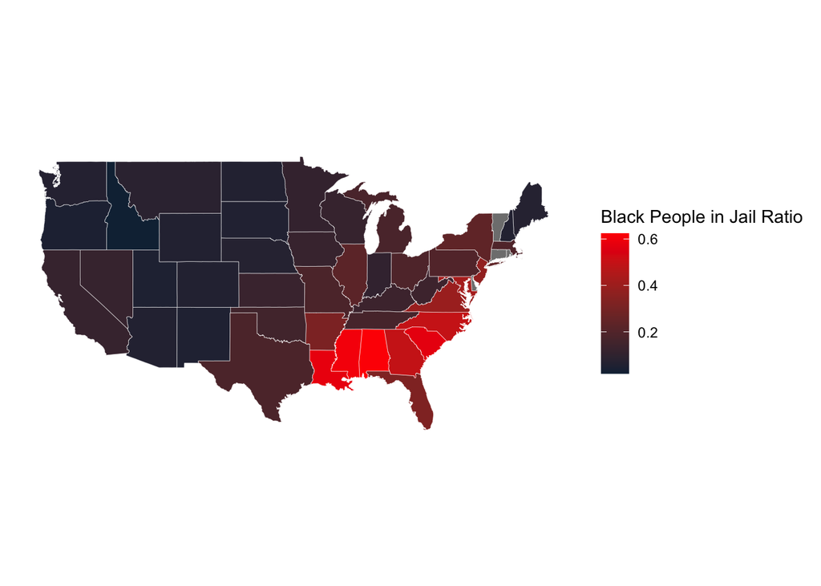